# CUNEF

### 6.7 GLM - SGD

```python
# Setting the model the model:
clf_sgd = SGDClassifier(loss = 'log_loss')
```

#### Fitting the model

```python
# Fitting the model
clf_sgd.fit(xtrain_processed2, ytrain_processed)
```

```
SGDClassifier(loss='log_loss')
```

#### Predict

```python
# Calculating the probs for each class:
y_pred_sgd_prob = clf_sgd.predict_proba(xtest_processed)
```

```
Best Threshold=0.782207, F2-Score=0.240
```

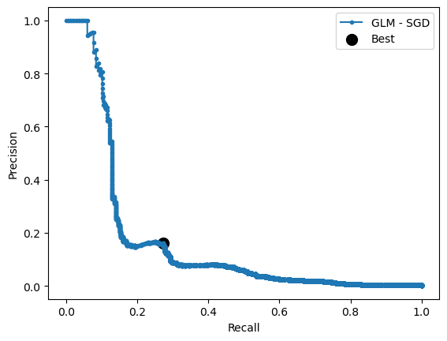

```python
# Plotting Precision-recall relation to maximize F2 Score:
plot_precision_recall_curve(ytest, y_pred_sgd_prob, 'GLM - SGD')
```

```python
# Set the proba threshold to get the predictions:
threshold = 0.78
y_pred_sgd = (y_pred_sgd_prob[:,1] >= threshold).astype('int')
```

#### Metrics

```python
# Metrics display:
show_metrics(ytest, y_pred_sgd, y_pred_sgd_prob,'GLM: SGD')
print("Classification Report")
print(classification_report(ytest, y_pred_sgd))
```

```
GLM: SGD metrics:
Accuracy:  0.9976
Precision:  0.1582
Recall:  0.2727
F2:  0.2382
AUC:  0.9355108894496653
Classification Report
              precision    recall  f1-score   support

           0       1.00      1.00      1.00    261858
           1       0.16      0.27      0.20       286

    accuracy                           1.00    262144
   macro avg       0.58      0.64      0.60    262144
weighted avg       1.00      1.00      1.00    262144
```

```python
# Train metrics display:
y_pred_sgd_prob_train = clf_sgd.predict_proba(xtrain_processed2)
y_pred_sgd_train = (y_pred_sgd_prob_train[:,1] >= threshold).astype('int')
show_metrics(ytrain_processed, y_pred_sgd_train, y_pred_sgd_prob_train, 'GLM-SGD')
```

```
GLM-SGD metrics:
Accuracy:  0.9286
Precision:  0.9383
Recall:  0.2299
F2:  0.2708
AUC:  0.9409443143529599
```

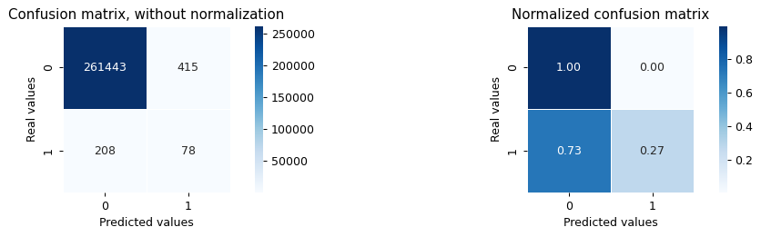

```python
# confusion matrix display:
confusion_matrix_plot(ytest, y_pred_sgd)
```

This model also fails to classify frauds well, and has a rather high overfitting as can be seen in the precision metric.

#### Pickle

```python
# Save the model as a pickle in a file
joblib.dump(clf_sgd, 'SGD.pkl')
```

```
['SGD.pkl']
```

**As we can see, the model with the best metrics(F2 and Recall) is xgboost. Therefore we are going to choose this model and we will do a tuning to find its best parameters.**

```python
show_metrics(ytest, y_pred_xgboost, y_pred_xgboost_prob, 'XGBOOST')
```

```
XGBOOST metrics:
Accuracy:  0.9997
Precision:  0.879
Recall:  0.8636
F2:  0.8667
AUC:  0.9962038358803017
```

### 6.8 Tunning XGBoost

```python
# Setting the model the model:
clf_xgboost_cv=XGBClassifier()
```

#### Fitting the model

```python
params = {
 'learning_rate' : [0.05, 0.10, 0.15, 0.20, 0.25, 0.30],
 'max_depth' : [3, 4, 5, 6, 8, 10, 12, 15],
 'min_child_weight' : [1, 3, 5, 7],
 'gamma': [0.0, 0.1, 0.2 , 0.3, 0.4],
 'colsample_bytree' : [0.3, 0.4, 0.5 , 0.7]
}
```

```python
## Randomized Search CV
clf_xgboost_cv=RandomizedSearchCV(clf_xgboost_cv, params,cv=5, random_state=1234, n_iter=5, n_jobs=-1)
```

```python
# Fitting the model
clf_xgboost_cv.fit(xtrain_processed2,ytrain_processed)
```

#### Predict

```python
# Calculating the probs for each class:
y_pred_xgboost_prob = clf_xgboost_cv.predict_proba(xtest_processed)
```

```
Best Threshold=0.212006, F2-Score=0.888
```

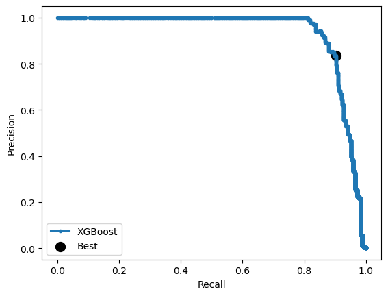

```python
# Plotting Precision-recall relation to maximize F2 Score:
plot_precision_recall_curve(ytest, y_pred_xgboost_prob, 'XGBoost')
```

```python
# Set the proba threshold to get the predictions:
threshold = 0.212
y_pred_xgboost = (y_pred_xgboost_prob[:,1] >= threshold).astype('int')
```

#### Metrics

```python
# Metrics display:
show_metrics(ytest, y_pred_xgboost, y_pred_xgboost_prob, 'XGBOOST')
print("Classification Report")
print(classification_report(ytest, y_pred_xgboost))
```

```
XGBOOST metrics:
Accuracy:  0.9997
Precision:  0.835
Recall:  0.9021
F2:  0.8878
AUC:  0.9966417099920755
Classification Report
              precision    recall  f1-score   support

           0       1.00      1.00      1.00    261858
           1       0.83      0.90      0.87       286

    accuracy                           1.00    262144
   macro avg       0.92      0.95      0.93    262144
weighted avg       1.00      1.00      1.00    262144
```

```python
# Train metrics display
y_pred_xgboost_prob_train = clf_xgboost_cv.predict_proba(xtrain_processed2)
y_pred_xgboost_train = (y_pred_xgboost_prob_train[:,1] >= threshold).astype('int')
show_metrics(ytrain_processed, y_pred_xgboost_train, y_pred_xgboost_prob_train, 'XGBOOST')
```

```
XGBOOST metrics:
Accuracy:  0.9999
Precision:  1.0
Recall:  0.9989
F2:  0.9991
AUC:  0.9999991530067367
```

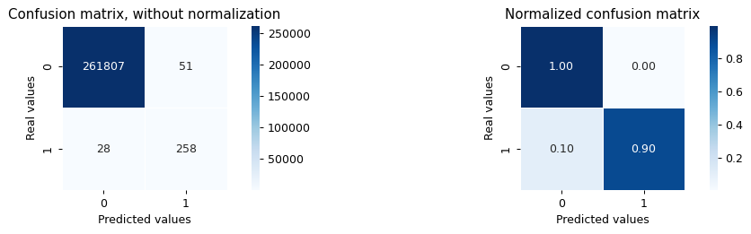

```python
# confusion matrix display:
confusion_matrix_plot(ytest, y_pred_xgboost)
```

[figure not shown]

```python
curves(ytest, y_pred_xgboost_prob)
```

As this is a very unbalanced problem, these curves do not provide much information, so we will not take them into account to decide whether the model is good or not.

#### Pickle

```python
# Save the model as a pickle in a file
joblib.dump(clf_xgboost_cv, 'clf_xgboost_cv.pkl')
```

```python
# load the model
# clf_xgboost_cv = joblib.load('clf_xgboost_cv.pkl')
```

## 7.Explicability

First of all, the global importance of the model variables from the xgboost will be shown and compared with the global importance obtained from the shap values.

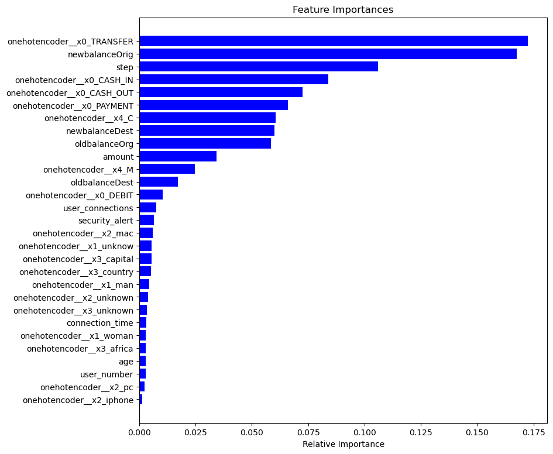

```python
importances =clf_xgboost_cv.best_estimator_.feature_importances_
#showing the most importance variables from the model
indices = np.argsort(importances)
features = xtrain_processed2.columns
plt.figure(figsize=(9,9))
plt.title('Feature Importances')
plt.barh(range(len(indices)), importances[indices], color='b', align='center')
plt.yticks(range(len(indices)), (features[i] for i in indices))
plt.xlabel('Relative Importance')
plt.show()
```